# análisis ovnis

Manuel Davo

19/3/2022

# ANÁLISIS EN R DE AVISTAMIENTOS OVNI

## Introducción

**El objetivo del trabajo es analizar un conjunto de datos. La sintáxis de dplyr, tidyr, la capacidad gráfica de ggplot2 o la de análisis de data.table será de gran ayuda.** **El análisis incluirá elementos numéricos y gráficos.** **El análisis debiera de ofrecer detalles de al menos sobre:**  
**i. Número de avistamientos por año y zona.**  
**ii. Duración media de los avistamientos, incluyento los tipos.**  
**iii. En el conjunto como véis hay coordenadas de longitud y latitud, que obviamente se prestan a un análisis geográfico. Como no hemos tratado nada de representación geográfica, podeís ignorar estos campos y centraros en el análisis de la columna país/estado.**  
**iv. Pero si alguno de vosotros se anima, os recomiendo el paquete ggmap, o el paquete leaflet.**  
**v. El paquete ggmap desde que Google cambió las condiciones de uso de sus datos geográficos necesita de que os déis de alta en su nube (dando de alta vuestra tarjeta de crédito), pero como en este caso, al disponerse de los valores de longitud/latitud se debiera de poder usar sin problemas. El paquete leaflet no presenta este problema.**  
**vi. Cualquier otro análisis adicional será valorado.**

## Datos a utilizar

# ANÁLISIS EN R DE AVISTAMIENTOS OVNI

Tenemos a nuestra disposición un conjunto de datos sobre avistamientos Ovni registrados desde inicios del sible XX, con el proceso de estos datos, vamos a intentar aportar algo de luz sobre el fenómeno Ovni contestando algunas cuestiones como:  
- ¿Qué parte de nuestro planeta es más visitada por los seres extraterrestres?  
- Con el paso del tiempo ¿nos visitan más o menos, los seres de otros planetas?  
- ¿En qué epoca del año, nuestro planeta es más visitado?  
- ¿Qué tipo de vehículo utilizan los visitantes para llegar a nuestro planeta?

Comenzamos Realizando un limpieza del entorno de trabajo y cargando todas las librerías que vamos a necesitar.

```r
# Limpieza del entorno de trabajo
rm(list = ls())

# Librerias necesarias
suppressWarnings(suppressPackageStartupMessages(library(dplyr)))
suppressWarnings(suppressPackageStartupMessages(library(ggplot2)))
suppressWarnings(suppressPackageStartupMessages(library(mclust)))
suppressWarnings(suppressPackageStartupMessages(library(lubridate)))
suppressWarnings(suppressPackageStartupMessages(library(maps)))
suppressWarnings(suppressPackageStartupMessages(library(mapdata)))
```

A continuación procedemos a cargar los datos aportados en fichero `.csv` con la función `read.csv`. Podemos observar que, como en efecto se apunta en el enunciado de la prueba, se trata de un dataframe con 11 variables, y un total de 88.875 observaciones. Para realizar el análisis seleccionamos tan sólo 9 de las 11 variables, dejando fuera del análisis los ‘comentarios’ (de la cual se podría realizar un análisis de texto) y la ‘duración en horas y minutos’ (al ser redundante con la variable ‘duración en segundos’).

```r
# Adquisición de datos
datos <- read.csv(file="D:/Big Data/miGit/avist_ovni.csv", header=T);
datos.sel <- datos %>%
  dplyr::select(latitude,
                longitude,
                shape,
                country,
                datetime,
                date.posted,
                city,
                state,
                duration = duration..seconds.)

str(datos.sel)
```

```
## 'data.frame':    88875 obs. of  9 variables:
##  $ latitude   : chr  "29.8830556" "29.38421" "53.2" "28.9783333" ...
##  $ longitude  : num  -97.94 -98.58 -2.92 -96.65 -157.8 ...
##  $ shape      : chr  "cylinder" "light" "circle" "circle" ...
##  $ country    : chr  "us" "" "gb" "us" ...
##  $ datetime   : chr  "10/10/1949 20:30" "10/10/1949 21:00" "10/10/1955 17:00" "10/10/1956 21:00" ...
##  $ date.posted: chr  "4/27/2004" "12/16/2005" "1/21/2008" "1/17/2004" ...
##  $ city       : chr  "san marcos" "lackland afb" "chester (uk/england)" "edna" ...
##  $ state      : chr  "tx" "tx" "" "tx" ...
##  $ duration   : chr  "2700" "7200" "20" "20" ...
```

En este paso vamos a realizar las transformaciones necesarias en las variables para poder operar con ellas de manera adecuada, dejamos como variables numéricas:  
- La duración en segundos  
- Latitud  
- Longitud  
Transformamos las variables de fecha y hora, con la librería `lubridate`. Y el resto lo convertimos a factor.

A continuación visualizamos la estructura para comprobar los cambios con `str()` y realizamos un `summary()` para comprobar los estadísticos básicos, en el propio summary podemos observar los distintos valores ‘NAs’ que nos pueden dar problemas a la hora de realizar el análisis

```r
# Reestructuración de datos
datos.sel$latitude <- as.numeric(as.character(datos.sel$latitude));
datos.sel$longitude <- as.numeric(as.character(datos.sel$longitude));
datos.sel$duration <- as.numeric(as.character(datos.sel$duration));
datos.sel$datetime <- mdy_hm(datos.sel$datetime);
datos.sel$date.posted <- mdy(datos.sel$date.posted);
datos.sel$country <- as.factor(datos.sel$country);
datos.sel$shape <- as.factor(datos.sel$shape);
datos.sel$city <- as.factor(datos.sel$city);
datos.sel$state <- as.factor(datos.sel$state);

# Visualización
str(datos.sel)
```

```
## 'data.frame':    88875 obs. of  9 variables:
##  $ latitude   : num  29.9 29.4 53.2 29 21.4 ...
##  $ longitude  : num  -97.94 -98.58 -2.92 -96.65 -157.8 ...
##  $ shape      : Factor w/ 30 levels "","changed","changing",..: 10 21 6 6 21 27 6 13 13 13 ...
##  $ country    : Factor w/ 6 levels "","au","ca","de",..: 6 1 5 6 6 6 5 6 6 6 ...
##  $ datetime   : POSIXct, format: "1949-10-10 20:30:00" "1949-10-10 21:00:00" ...
##  $ date.posted: Date, format: "2004-04-27" "2005-12-16" ...
##  $ city       : Factor w/ 22019 levels "","&ccedil;anakkale (turkey)",..: 17242 10140 3534 5623 9488 2350 15072 14026 15056 10963 ...
##  $ state      : Factor w/ 69 levels "","ab","ak","al",..: 59 59 1 59 15 58 1 10 4 13 ...
##  $ duration   : num  2700 7200 20 20 900 300 180 1200 180 120 ...
```

```r
summary(datos.sel)
```

```
##     latitude        longitude            shape       country
##  Min.   :-82.86   Min.   :-176.66   light   :17872     :12561
##  1st Qu.: 34.03   1st Qu.:-112.05   triangle: 8489   au:  593
##  Median : 39.23   Median : -87.65   circle  : 8453   ca: 3266
##  Mean   : 37.45   Mean   : -84.83   fireball: 6562   de:  112
##  3rd Qu.: 42.72   3rd Qu.: -77.62   unknown : 6319   gb: 2050
##  Max.   : 72.70   Max.   : 178.44   other   : 6247   us:70293
##  NA's   :197                        (Other) :34933
##     datetime                    date.posted                  city
##  Min.   :1906-11-11 00:00:00   Min.   :1998-03-07   seattle    :  570
##  1st Qu.:2001-06-13 23:00:00   1st Qu.:2003-10-31   phoenix    :  488
##  Median :2006-09-28 01:40:00   Median :2007-10-08   portland   :  399
##  Mean   :2004-03-17 19:09:46   Mean   :2007-06-30   las vegas  :  395
##  3rd Qu.:2011-05-15 03:50:00   3rd Qu.:2011-10-10   los angeles:  375
##  Max.   :2014-05-08 18:45:00   Max.   :2022-10-05   san diego  :  361
##  NA's   :518                   NA's   :194          (Other)    :86287
##      state          duration
##  ca     :10450   Min.   :       0
##         : 7519   1st Qu.:      15
##  wa     : 4653   Median :     120
##  fl     : 4598   Mean   :    8373
##  tx     : 4050   3rd Qu.:     600
##  ny     : 3511   Max.   :97836000
##  (Other):54094   NA's   :5
```

Procedemos a eliminar los datos omitidos creando un nuevo dataset con datos limpios. Como podemos comprobar, tan sólo se eliminan 703 observaciones, que comparado con la dimensión del dataset inicial (88.875) no supone ni siquiera el 1%. Por lo que consideramos factible la eliminación de tales observaciones sin que afecte significativamente a los resultados. Realizamos un nuevo `summary` comprobando que los estadisticos básicos no varían.

```r
# Datos sin NAs
datos.limp <- na.omit(datos.sel);

print('El número de observaciones de datos seleccionados es:')
```

```
## [1] "El número de observaciones de datos seleccionados es:"
```

```r
nrow(datos.sel)
```

```
## [1] 88875
```

```r
print('El número de observaciones de datos limpios es:')
```

```
## [1] "El número de observaciones de datos limpios es:"
```

```r
nrow(datos.limp)
```

```
## [1] 88172
```

```r
print('El númerp de observaciones elimindas es de:')
```

```
## [1] "El númerp de observaciones elimindas es de:"
```

```r
nrow(datos.sel)-nrow(datos.limp)
```

```
## [1] 703
```

```r
summary(datos.limp)
```

```
##     latitude        longitude            shape       country
##  Min.   :-82.86   Min.   :-173.99   light   :17827     :12234
##  1st Qu.: 34.05   1st Qu.:-112.07   triangle: 8456   au:  588
##  Median : 39.24   Median : -87.65   circle  : 8400   ca: 3252
##  Mean   : 37.46   Mean   : -85.08   fireball: 6540   de:  110
##  3rd Qu.: 42.72   3rd Qu.: -77.80   unknown : 6270   gb: 2031
##  Max.   : 72.70   Max.   : 178.44   other   : 6219   us:69957
##                                     (Other) :34460
##     datetime                    date.posted                  city
##  Min.   :1906-11-11 00:00:00   Min.   :1998-03-07   seattle    :  565
##  1st Qu.:2001-06-13 21:56:15   1st Qu.:2003-10-31   phoenix    :  486
##  Median :2006-09-28 03:00:30   Median :2007-10-08   portland   :  399
##  Mean   :2004-03-18 10:01:50   Mean   :2007-07-02   las vegas  :  395
##  3rd Qu.:2011-05-16 00:07:30   3rd Qu.:2011-10-10   los angeles:  375
##  Max.   :2014-05-08 18:45:00   Max.   :2014-05-08   san diego  :  359
##                                                     (Other)    :85593
##      state          duration
##  ca     :10407   Min.   :       0
##         : 7312   1st Qu.:      15
##  wa     : 4625   Median :     120
##  fl     : 4576   Mean   :    7583
##  tx     : 4008   3rd Qu.:     600
##  ny     : 3488   Max.   :97836000
##  (Other):53756
```

Comenzamos el análisis mostrando el número de avistamientos en función de los países.

```r
# Avistamientos por países
levels(datos.limp$country) <- c("Resto", "Australia", "Canada", "Alemania", "Reino Unido", "USA");

# Tabla
table(datos.limp$country)
```

```
##
##       Resto   Australia      Canada    Alemania Reino Unido         USA
##       12234         588        3252         110        2031       69957
```

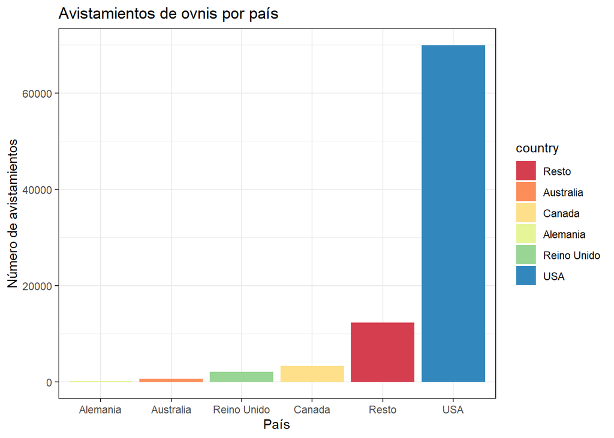

```r
# Gráfico
ggplot(datos.limp, aes(x=reorder(country, country, FUN=length), fill=country)) +
  stat_count() +
  theme_bw() +
  scale_fill_brewer(palette="Spectral") +
  labs(x = "País", y = "Número de avistamientos",
     title="Avistamientos de ovnis por país")
```

En el siguiente gráfico podemos ver la densidad de avistamientos a nivel mundial y en función de la fecha.

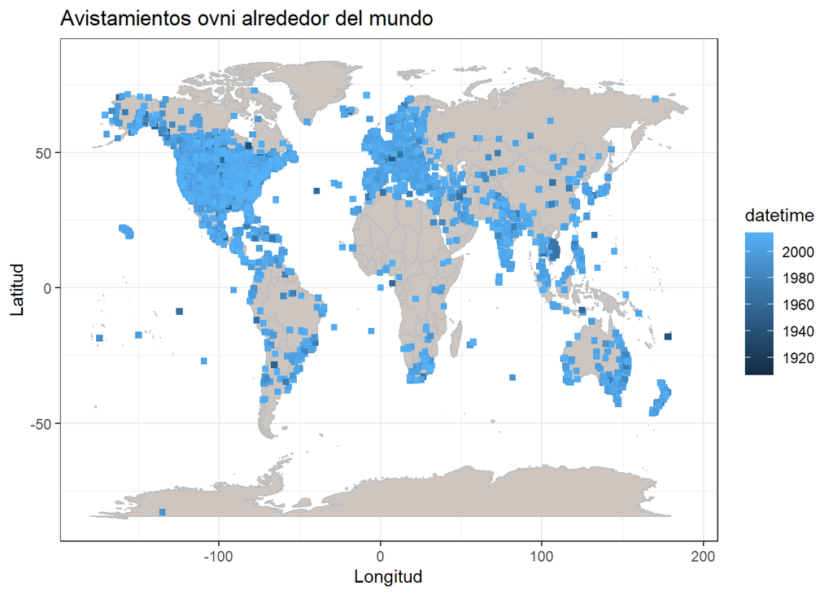

```r
# Densidad de avistamientos a nivel mundial
ggplot(datos.limp, aes(x=longitude, y=latitude, colour=datetime)) +
  borders("world", colour="gray", fill="seashell3") +
  geom_point(shape=15) +
  theme_bw() +
  labs(x = "Longitud", y = "Latitud",
       title="Avistamientos ovni alrededor del mundo")
```

En función de la latitud y longitud, podemos comprobar que la mayor parte corresponde Estados Unidos, seguido de Europa.

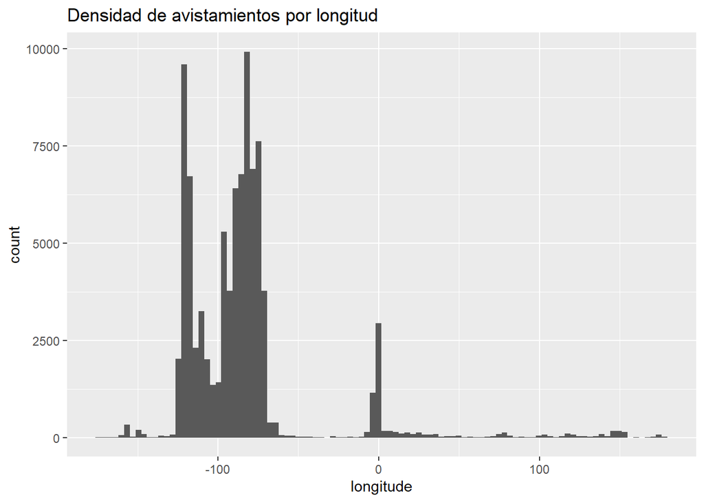

```r
# Longitud
ggplot(datos.limp, aes(longitude)) +
    geom_histogram(bins = 100) +
    ggtitle("Densidad de avistamientos por longitud")
```

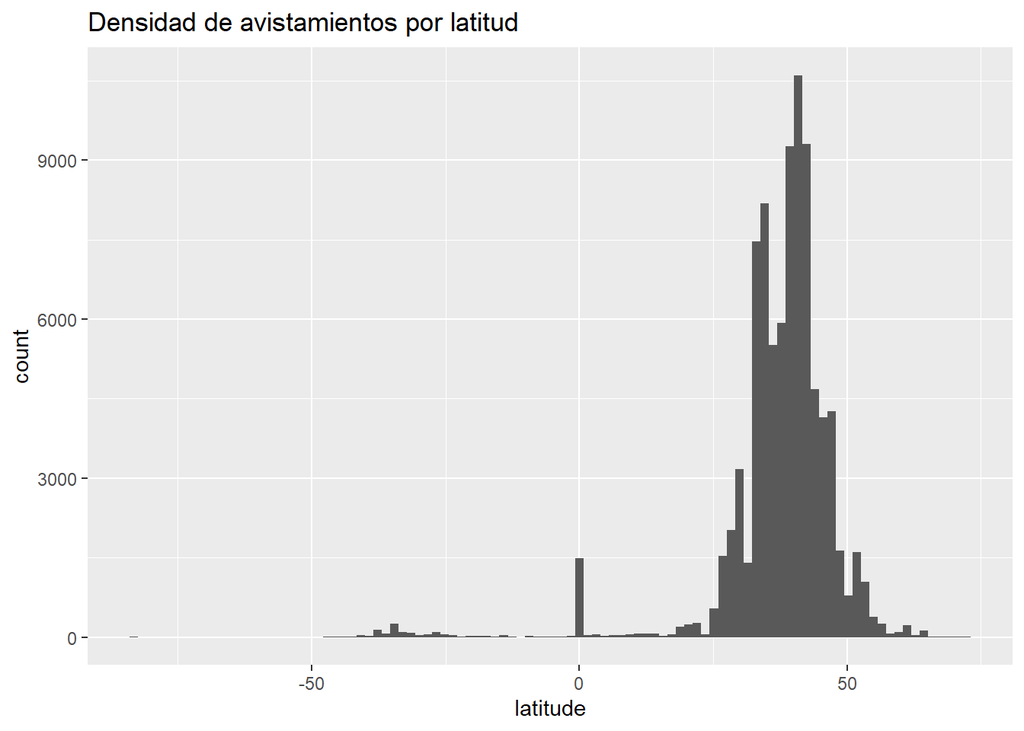

```r
# Latitud
ggplot(datos.limp, aes(latitude)) +
    geom_histogram(bins = 100) +
    ggtitle("Densidad de avistamientos por latitud")
```

Estos primero gráficos nos pueden dar respuesta a nuestra primera pregunta, mostrando que la mayor parte de los avistamientos se producen en zona muy pobladas, aunque no podemos afirmar que esta gran densidad de avistamientos se corresponda con una mayor presencia extraterrestre, sina más bien, a que en estas zonas residen más individuos que pueden ver cosas extrañas en el firmamento.

Teniendo en cuenta la fecha de avistamiento, a continuación graficamos los avistamientos en función de su fecha (verde) y de su registro (rojo), comprobamos que los datos se disparan a partir de la década de los 90.

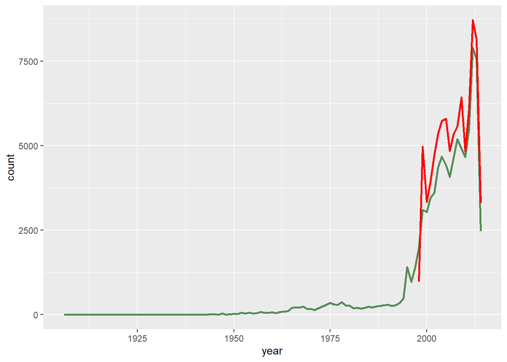

```r
# Aistamientos por año
avist.anio <-
  datos.limp %>% group_by(year=year(datetime)) %>%
  summarize(count=n());

# Informes por año
reports.anio <-
  datos.limp %>% group_by(year=year(date.posted)) %>%
  summarize(count=n());
ggplot(avist.anio, aes(x=year, y=count)) +
  geom_line(size=1, colour="palegreen4") +
  geom_line(data=reports.anio, aes(y=count), size=1, colour="red")
```

El gráfico anterior nos da respuesta a nuestra segunda cuestión, con el paso del tiempo, hay un incremento notable del fenómeno Ovni, poniendo de manifiesto que, o nuestro planeta se está poniendo de moda en las visitas interestelares, o lo que se pone de moda es mirar al cielo por cada vez mayor número de personas.

Como hemos podido comprobar, Estados Unidos es con diferencia el país con mayor número de avistamientos, por lo que realizamos un análisis específico de este país

```r
## Avistamientos en USA
# Extracción datos US
datos.US <- filter(datos.limp, country=="USA" & !(state %in% c("ak", "hi", "pr")));

# Tabla
table(datos.US$state)
```

```
##
##        ab   ak   al   ar   az   bc   ca   co   ct   dc   de   fl   ga   hi   ia
##    0    0    0  702  636 2610    0 9539 1515  968    7  180 4137 1354    0  731
##   id   il   in   ks   ky   la   ma   mb   md   me   mi   mn   mo   ms   mt   nb
##  566 2684 1400  647  926  588 1332    0  888  594 1974 1090 1564  410  528    0
##   nc   nd   ne   nf   nh   nj   nm   ns   nt   nv   ny   oh   ok   on   or   pa
## 1854  139  413    0  517 1347  787    0    0  857 3217 2448  774    0 1865 2514
##   pe   pq   pr   qc   ri   sa   sc   sd   sk   tn   tx   ut   va   vi   vt   wa
##    0    0    0    0  243    0 1074  193    0 1224 3714  655 1374    0  283 4268
##   wi   wv   wy   yk   yt
## 1305  493  189    0    0
```

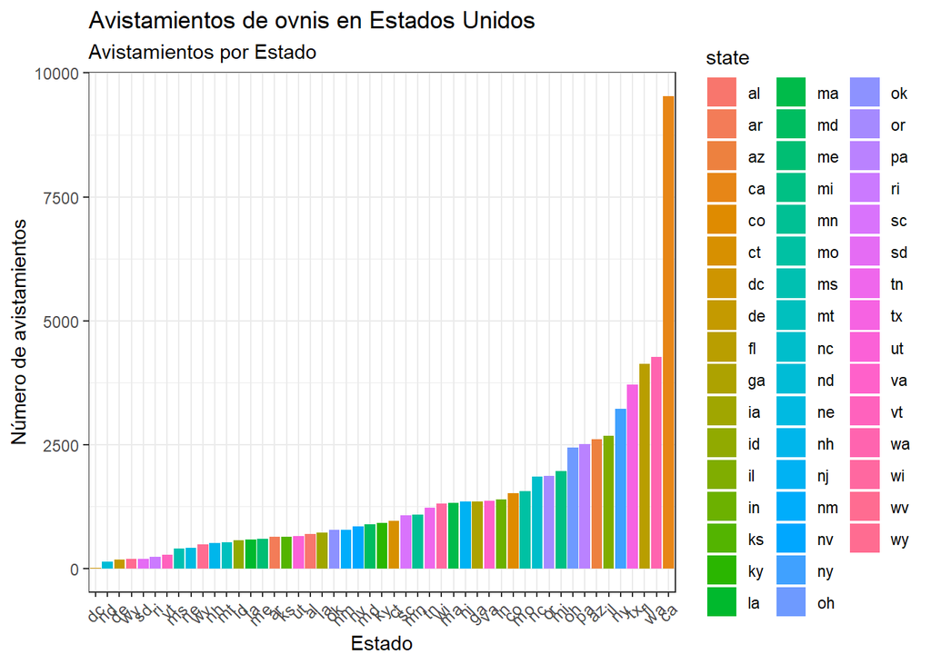

```r
# Gráfico
ggplot(datos.US, aes(x=reorder(state, state, FUN=length), fill=state)) +
  stat_count() +
  theme_bw() +
  theme(axis.text.x = element_text(angle=45, size=9, hjust=1)) +
  labs(x = "Estado", y = "Número de avistamientos",
       title="Avistamientos de ovnis en Estados Unidos",
       subtitle = "Avistamientos por Estado")
```

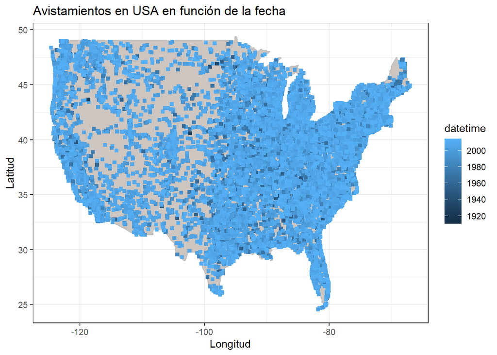

```r
# Avistamientos por fecha
ggplot(datos.US, aes(x=longitude, y=latitude, colour=datetime)) +
  borders("usa", colour="gray", fill="seashell3") +
  geom_point(shape=15) +
  theme_bw() +
  labs(x = "Longitud", y = "Latitud",
       title="Avistamientos en USA en función de la fecha")
```

A continuación realizamos el análisis de los avistamientos dependiendo de la hora del día en la que se realizan. Comprobando que la mayoría de ellos se producen cuando el sol se está poniendo y en las primera horas de la noche.

```r
# Tabla hora del día
table(hour(datos.limp$datetime))
```

```
##
##     0     1     2     3     4     5     6     7     8     9    10    11    12
##  5318  3581  2623  2219  1695  1738  1328  1034   917  1095  1331  1306  1601
##    13    14    15    16    17    18    19    20    21    22    23
##  1499  1479  1595  1810  2816  4367  6654  9322 12299 11747  8798
```

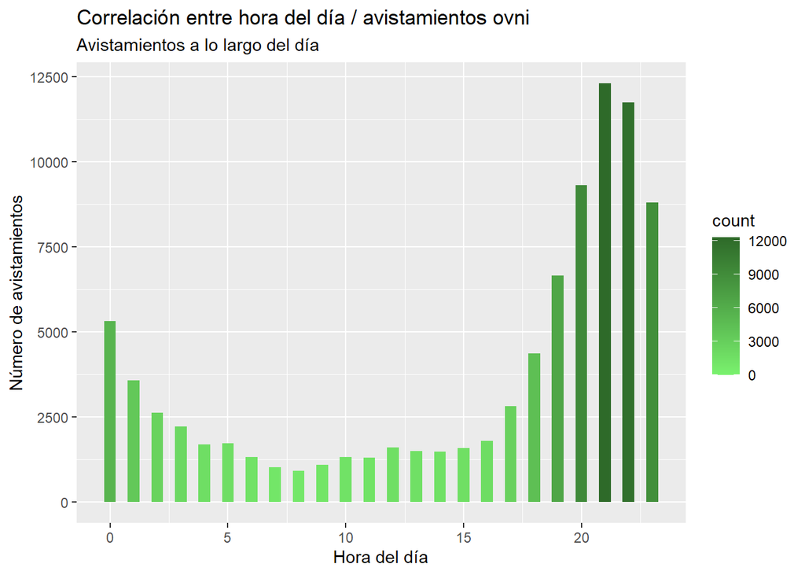

```r
# Gráfico hora
ggplot(datos.limp, aes(x=hour(datetime))) +
  geom_histogram(bins=47, aes(fill=..count..)) +
  theme_grey() +
  scale_fill_gradient(low = "#7AF26E", high = "#2E6A29") +
  labs(x = "Hora del día", y = "Número de avistamientos",
       title="Correlación entre hora del día / avistamientos ovni",
       subtitle = "Avistamientos a lo largo del día")
```

Realizamos similar análisis con los días del mes, obteniendo un dato curioso, y es que los días 1 y 15 de cada mes, hay un repunte en los avistamientos.

```r
# Tabla día
tab.dia <- table(mday(datos.limp$datetime))
tab.dia
```

```
##
##    1    2    3    4    5    6    7    8    9   10   11   12   13   14   15   16
## 6180 2383 2568 3365 2678 2508 2607 2507 2362 3119 2524 2836 2706 2711 6566 2832
##   17   18   19   20   21   22   23   24   25   26   27   28   29   30   31
## 2507 2521 2589 3338 2465 2556 2527 2522 2704 2258 2260 2503 2212 2864 1894
```

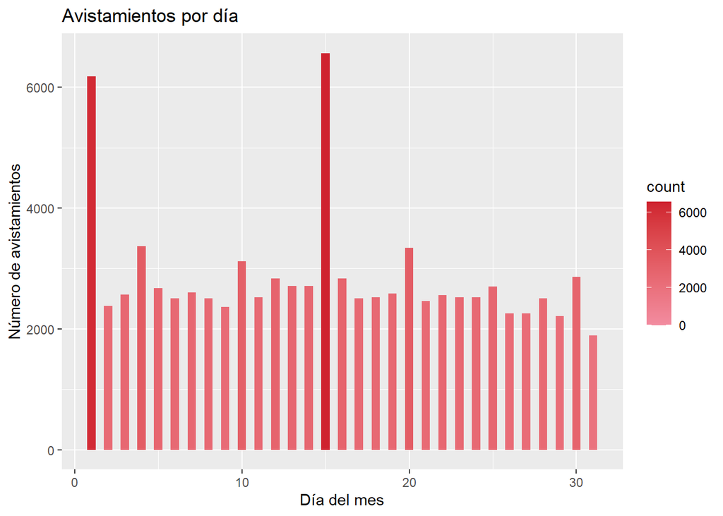

```r
# Gráfico día
ggplot(datos.limp, aes(x=mday(datetime))) +
  geom_histogram(bins=61, aes(fill=..count..)) +
  theme_grey() +
  scale_fill_gradient(low = "#F28CA0", high = "#CF222F") +
  labs(x = "Día del mes", y = "Número de avistamientos",
       title="Avistamientos por día")
```

A continuación realizamos un análisis similar al anterior, pero esta vez teniendo en cuenta el mes del año en el que se producen los avistamientos.  
La siguiente tabla y gráfico, dan respuesta a nuestra tercera cuestión, revelando que en los meses de verano, los avistamientos Ovni tienen un repunte, este análisis no puede dar respuesta a si dicho repunte se debe a que las visitas de seres extraterrestres son por motivos turísticos, o que los meses de verano son más propicios para los terrícolas a a tumbarse en una hamaca mirando al cielo mientras se produce un aumento de la ingesta de bebidas alcohólicas. Lo que puede desembocar en un lógico incremento de avistamientos Ovni.

```r
# Tabla mes
meses <- c('Enero', 'Febrero', 'Marzo', 'Abril', 'Mayo', 'Junio', 'Julio', 'Agosto', 'Septiembre', 'Octubre', 'Noviembre', 'Diciembre')
tab.month <- table(month(datos.limp$datetime))
rownames(tab.month) <- meses
tab.month
```

```
##
##      Enero    Febrero      Marzo      Abril       Mayo      Junio      Julio
##       6319       5147       5988       6053       5847       9006      10368
##     Agosto Septiembre    Octubre  Noviembre  Diciembre
##       9384       8285       8140       7409       6226
```

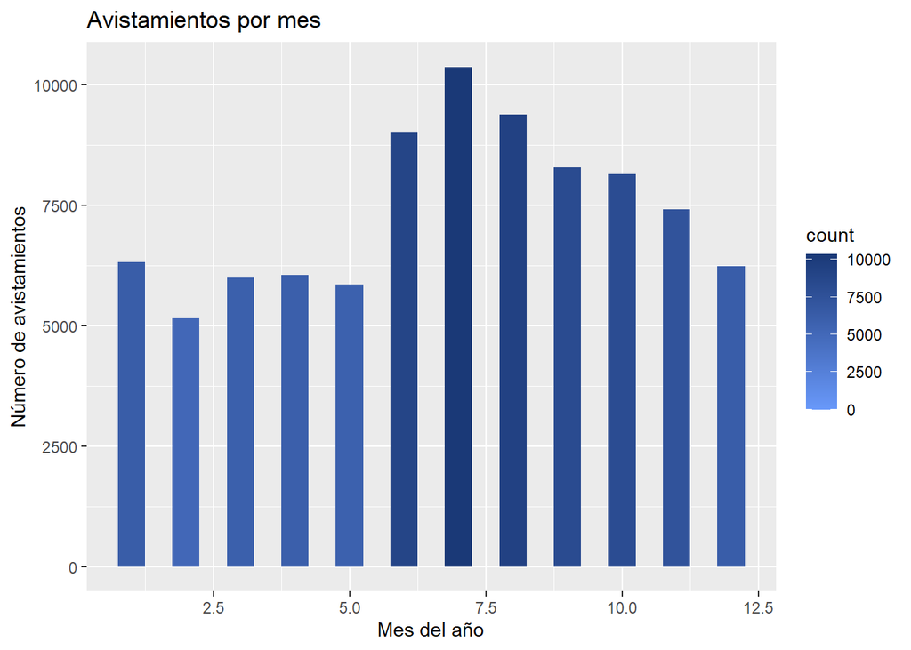

```r
# Gráfico mes
ggplot(datos.limp, aes(x=month(datetime))) +
  geom_histogram(bins=23, aes(fill=..count..)) +
  theme_grey() +
  scale_fill_gradient(low = "#6999FA", high = "#1A3977") +
  labs(x = "Mes del año", y = "Número de avistamientos",
       title="Avistamientos por mes")
```

```r
# Tabla formas por países
tab.pais.forma <- table(datos.limp$country,datos.limp$shape)
tab.pais.forma
```

```
##
##                     changed changing chevron cigar circle  cone crescent cross
##   Resto         525       0      300     112   322   1140    55        1    29
##   Australia      16       0       10       3    17     68     8        0     3
##   Canada         57       0       73      38    76    306    13        0     9
##   Alemania        2       0        2       1     3      9     0        0     0
##   Reino Unido    57       0       47      10    68    256    13        0    10
##   USA          2156       1     1700     839  1740   6621   277        1   213
##
##               cylinder delta diamond  disk  dome   egg fireball flare flash
##   Resto            193     0     191  1040     1   134      794     0   205
##   Australia         10     0      11    62     0    12       36     0     4
##   Canada            56     1      49   216     0    29      227     0    67
##   Alemania           3     0       3     6     0     2       10     0     1
##   Reino Unido       31     0      48   111     0    35      121     0    29
##   USA             1083     7    1000  4523     0   629     5352     1  1165
##
##               formation hexagon light other  oval pyramid rectangle round
##   Resto             351       0  2348   943   572       0       189     0
##   Australia          20       0   122    42    32       0        13     0
##   Canada            103       0   706   270   143       0        52     0
##   Alemania            3       0    23     9     8       0         1     0
##   Reino Unido        65       0   386   138    93       0        31     0
##   USA              2108       1 14242  4817  3247       1      1125     2
##
##               sphere teardrop triangle unknown
##   Resto          816      111      999     863
##   Australia       15       10       47      27
##   Canada         215       23      290     233
##   Alemania         7        0        9       8
##   Reino Unido    165       39      180      98
##   USA           4502      632     6931    5041
```

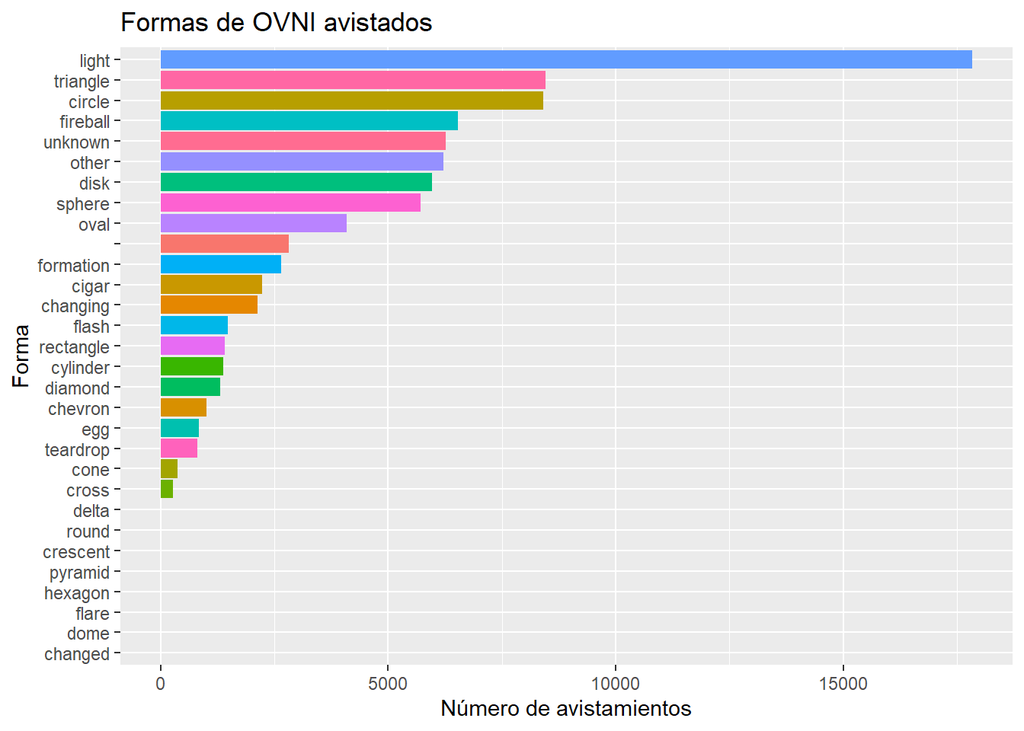

```r
# Formas de Ovnis más vistas
ggplot(datos.limp, aes(x=reorder(shape, shape, FUN=length), fill=shape)) +
  geom_bar(show.legend=F) +
  coord_flip() +
  theme_grey() +
  labs(x = "Forma", y = "Número de avistamientos",
       title="Formas de OVNI avistados")
```

En el siguiente mapa mundial en función de la forma del avistamiento no parece que haya una correlación entre la zona del avistamiento y la forma del Ovni.

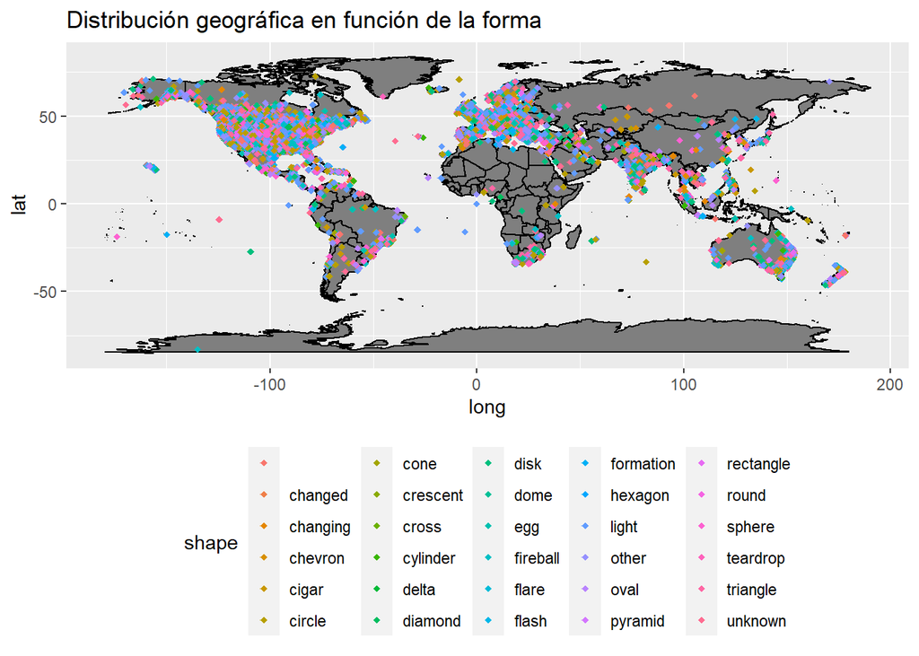

```r
# Mapa en función de la forma
map <- borders("world", colour="black", fill="gray50")
ufo_map <- ggplot(datos.limp) + map
print(ufo_map + geom_point(aes(x=datos.limp$longitude, y=datos.limp$latitude,color=shape),shape=18) +
        theme(legend.position = "bottom")+
        ggtitle("Distribución geográfica en función de la forma"))
```

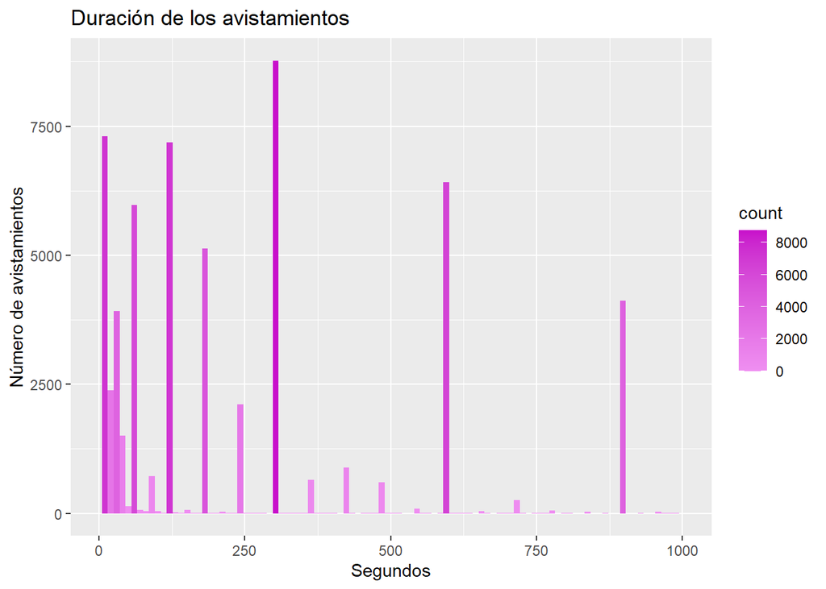

```r
# Histograma por duración
ggplot(datos.limp, aes(x = duration)) +
  geom_histogram(bins = 100, aes(fill=..count..)) +
  theme_grey() +
  scale_fill_gradient(low = "#EF8FF1", high = "#C810CB") +
  scale_x_continuous(limits = c(1,1000)) +
  labs(x = "Segundos", y = "Número de avistamientos",
       title="Duración de los avistamientos")
```